# Risk Factor Analysis

## Outcome Variable

**Outcome Variable:** ever_sstunted

## Predictor Variables

**Intervention Variable:** sex

**Adjustment Set:**

unadjusted

## Stratifying Variables

The analysis was stratified on these variable(s):

- agecat
- studyid
- country

## Data Summary

| agecat | studyid | country | sex | ever_sstunted | n_cell | n |
| --- | --- | --- | --- | --- | --- | --- |
| 0-24 months | ki0047075b-MAL-ED | BANGLADESH | Female | 0 | 111 | 265 |
| 0-24 months | ki0047075b-MAL-ED | BANGLADESH | Female | 1 | 25 | 265 |
| 0-24 months | ki0047075b-MAL-ED | BANGLADESH | Male | 0 | 97 | 265 |
| 0-24 months | ki0047075b-MAL-ED | BANGLADESH | Male | 1 | 32 | 265 |
| 0-24 months | ki0047075b-MAL-ED | BRAZIL | Female | 0 | 106 | 233 |
| 0-24 months | ki0047075b-MAL-ED | BRAZIL | Female | 1 | 7 | 233 |
| 0-24 months | ki0047075b-MAL-ED | BRAZIL | Male | 0 | 109 | 233 |
| 0-24 months | ki0047075b-MAL-ED | BRAZIL | Male | 1 | 11 | 233 |
| 0-24 months | ki0047075b-MAL-ED | INDIA | Female | 0 | 115 | 251 |
| 0-24 months | ki0047075b-MAL-ED | INDIA | Female | 1 | 23 | 251 |
| 0-24 months | ki0047075b-MAL-ED | INDIA | Male | 0 | 80 | 251 |
| 0-24 months | ki0047075b-MAL-ED | INDIA | Male | 1 | 33 | 251 |
| 0-24 months | ki0047075b-MAL-ED | NEPAL | Female | 0 | 102 | 240 |
| 0-24 months | ki0047075b-MAL-ED | NEPAL | Female | 1 | 8 | 240 |
| 0-24 months | ki0047075b-MAL-ED | NEPAL | Male | 0 | 117 | 240 |
| 0-24 months | ki0047075b-MAL-ED | NEPAL | Male | 1 | 13 | 240 |
| 0-24 months | ki0047075b-MAL-ED | PERU | Female | 0 | 118 | 303 |
| 0-24 months | ki0047075b-MAL-ED | PERU | Female | 1 | 25 | 303 |
| 0-24 months | ki0047075b-MAL-ED | PERU | Male | 0 | 121 | 303 |
| 0-24 months | ki0047075b-MAL-ED | PERU | Male | 1 | 39 | 303 |
| 0-24 months | ki0047075b-MAL-ED | SOUTH AFRICA | Female | 0 | 127 | 314 |
| 0-24 months | ki0047075b-MAL-ED | SOUTH AFRICA | Female | 1 | 32 | 314 |
| 0-24 months | ki0047075b-MAL-ED | SOUTH AFRICA | Male | 0 | 115 | 314 |
| 0-24 months | ki0047075b-MAL-ED | SOUTH AFRICA | Male | 1 | 40 | 314 |
| 0-24 months | ki0047075b-MAL-ED | TANZANIA, UNITED REPUBLIC OF | Female | 0 | 71 | 262 |
| 0-24 months | ki0047075b-MAL-ED | TANZANIA, UNITED REPUBLIC OF | Female | 1 | 62 | 262 |
| 0-24 months | ki0047075b-MAL-ED | TANZANIA, UNITED REPUBLIC OF | Male | 0 | 56 | 262 |
| 0-24 months | ki0047075b-MAL-ED | TANZANIA, UNITED REPUBLIC OF | Male | 1 | 73 | 262 |
| 0-24 months | ki1000108-CMC-V-BCS-2002 | INDIA | Female | 0 | 80 | 373 |
| 0-24 months | ki1000108-CMC-V-BCS-2002 | INDIA | Female | 1 | 107 | 373 |

[output cut: 238 more lines]

The following strata were considered:

- agecat: 0-24 months, studyid: ki0047075b-MAL-ED, country: BANGLADESH
- agecat: 0-24 months, studyid: ki0047075b-MAL-ED, country: BRAZIL
- agecat: 0-24 months, studyid: ki0047075b-MAL-ED, country: INDIA
- agecat: 0-24 months, studyid: ki0047075b-MAL-ED, country: NEPAL
- agecat: 0-24 months, studyid: ki0047075b-MAL-ED, country: PERU
- agecat: 0-24 months, studyid: ki0047075b-MAL-ED, country: SOUTH AFRICA
- agecat: 0-24 months, studyid: ki0047075b-MAL-ED, country: TANZANIA, UNITED REPUBLIC OF
- agecat: 0-24 months, studyid: ki1000108-CMC-V-BCS-2002, country: INDIA
- agecat: 0-24 months, studyid: ki1000108-IRC, country: INDIA
- agecat: 0-24 months, studyid: ki1000109-EE, country: PAKISTAN
- agecat: 0-24 months, studyid: ki1000109-ResPak, country: PAKISTAN
- agecat: 0-24 months, studyid: ki1000304b-SAS-CompFeed, country: INDIA
- agecat: 0-24 months, studyid: ki1000304b-SAS-FoodSuppl, country: INDIA
- agecat: 0-24 months, studyid: ki1017093-NIH-Birth, country: BANGLADESH
- agecat: 0-24 months, studyid: ki1017093b-PROVIDE, country: BANGLADESH
- agecat: 0-24 months, studyid: ki1017093c-NIH-Crypto, country: BANGLADESH
- agecat: 0-24 months, studyid: ki1066203-TanzaniaChild2, country: TANZANIA, UNITED REPUBLIC OF
- agecat: 0-24 months, studyid: ki1101329-Keneba, country: GAMBIA
- agecat: 0-24 months, studyid: ki1112895-Guatemala BSC, country: GUATEMALA
- agecat: 0-24 months, studyid: ki1112895-iLiNS-Zinc, country: BURKINA FASO
- agecat: 0-24 months, studyid: ki1113344-GMS-Nepal, country: NEPAL
- agecat: 0-24 months, studyid: ki1114097-CMIN, country: BANGLADESH
- agecat: 0-24 months, studyid: ki1114097-CMIN, country: BRAZIL
- agecat: 0-24 months, studyid: ki1114097-CMIN, country: GUINEA-BISSAU
- agecat: 0-24 months, studyid: ki1114097-CMIN, country: PERU
- agecat: 0-24 months, studyid: ki1114097-CONTENT, country: PERU
- agecat: 0-24 months, studyid: ki1119695-PROBIT, country: BELARUS
- agecat: 0-24 months, studyid: ki1126311-ZVITAMBO, country: ZIMBABWE
- agecat: 0-24 months, studyid: ki1135781-COHORTS, country: GUATEMALA
- agecat: 0-24 months, studyid: ki1135781-COHORTS, country: INDIA
- agecat: 0-24 months, studyid: ki1135781-COHORTS, country: PHILIPPINES
- agecat: 0-24 months, studyid: ki1148112-LCNI-5, country: MALAWI
- agecat: 0-24 months, studyid: kiGH5241-JiVitA-3, country: BANGLADESH
- agecat: 0-24 months, studyid: kiGH5241-JiVitA-4, country: BANGLADESH
- agecat: 0-6 months, studyid: ki0047075b-MAL-ED, country: BANGLADESH
- agecat: 0-6 months, studyid: ki0047075b-MAL-ED, country: BRAZIL
- agecat: 0-6 months, studyid: ki0047075b-MAL-ED, country: INDIA
- agecat: 0-6 months, studyid: ki0047075b-MAL-ED, country: NEPAL
- agecat: 0-6 months, studyid: ki0047075b-MAL-ED, country: PERU
- agecat: 0-6 months, studyid: ki0047075b-MAL-ED, country: SOUTH AFRICA
- agecat: 0-6 months, studyid: ki0047075b-MAL-ED, country: TANZANIA, UNITED REPUBLIC OF
- agecat: 0-6 months, studyid: ki1000108-CMC-V-BCS-2002, country: INDIA
- agecat: 0-6 months, studyid: ki1000108-IRC, country: INDIA
- agecat: 0-6 months, studyid: ki1000109-EE, country: PAKISTAN
- agecat: 0-6 months, studyid: ki1000109-ResPak, country: PAKISTAN
- agecat: 0-6 months, studyid: ki1000304b-SAS-CompFeed, country: INDIA
- agecat: 0-6 months, studyid: ki1000304b-SAS-FoodSuppl, country: INDIA
- agecat: 0-6 months, studyid: ki1017093-NIH-Birth, country: BANGLADESH
- agecat: 0-6 months, studyid: ki1017093b-PROVIDE, country: BANGLADESH
- agecat: 0-6 months, studyid: ki1017093c-NIH-Crypto, country: BANGLADESH
- agecat: 0-6 months, studyid: ki1066203-TanzaniaChild2, country: TANZANIA, UNITED REPUBLIC OF
- agecat: 0-6 months, studyid: ki1101329-Keneba, country: GAMBIA
- agecat: 0-6 months, studyid: ki1112895-Guatemala BSC, country: GUATEMALA
- agecat: 0-6 months, studyid: ki1113344-GMS-Nepal, country: NEPAL
- agecat: 0-6 months, studyid: ki1114097-CMIN, country: BANGLADESH
- agecat: 0-6 months, studyid: ki1114097-CMIN, country: BRAZIL
- agecat: 0-6 months, studyid: ki1114097-CMIN, country: GUINEA-BISSAU
- agecat: 0-6 months, studyid: ki1114097-CMIN, country: PERU
- agecat: 0-6 months, studyid: ki1114097-CONTENT, country: PERU
- agecat: 0-6 months, studyid: ki1119695-PROBIT, country: BELARUS
- agecat: 0-6 months, studyid: ki1126311-ZVITAMBO, country: ZIMBABWE
- agecat: 0-6 months, studyid: ki1135781-COHORTS, country: GUATEMALA
- agecat: 0-6 months, studyid: ki1135781-COHORTS, country: INDIA
- agecat: 0-6 months, studyid: ki1135781-COHORTS, country: PHILIPPINES
- agecat: 0-6 months, studyid: ki1148112-LCNI-5, country: MALAWI
- agecat: 0-6 months, studyid: kiGH5241-JiVitA-3, country: BANGLADESH
- agecat: 0-6 months, studyid: kiGH5241-JiVitA-4, country: BANGLADESH

### Dropped Strata

Some strata were dropped due to rare outcomes:

- agecat: 0-24 months, studyid: ki1114097-CONTENT, country: PERU
- agecat: 0-6 months, studyid: ki0047075b-MAL-ED, country: NEPAL
- agecat: 0-6 months, studyid: ki1114097-CMIN, country: BRAZIL
- agecat: 0-6 months, studyid: ki1114097-CONTENT, country: PERU
- agecat: 0-6 months, studyid: ki1148112-LCNI-5, country: MALAWI

## Methods Detail

We’re interested in the causal parameters $E[Y_a]$ for all values of $a \in \mathcal{A}$. These parameters represent the mean outcome if, possibly contrary to fact, we intervened to set all units to have $A=a$. Under the randomization and positivity assumptions, these are identified by the statistical parameters $\psi_a=E_W[E_{Y|A,W}(Y|A=a,W)]$. In addition, we’re interested in the mean of $Y$, $E[Y]$ under no intervention (the observed mean). We will estimate these parameters by using SuperLearner to fit the relevant likelihood factors – $E_{Y|A,W}(Y|A=a,W)$ and $p(A=a|W)$, and then updating our likelihood fit using a joint TMLE.

For unadjusted analyses ($W=\{\}$), initial likelihoods were estimated using Lrnr_glm to estimate the simple $E(Y|A)$ and Lrnr_mean to estimate $p(A)$. For adjusted analyses, a small library containing Lrnr_glmnet, Lrnr_xgboost, and Lrnr_mean was used.

Having estimated these parameters, we will then use the delta method to estimate relative risks and attributable risks relative to a prespecified baseline level of $A$.

# Results Detail

## Results Plots

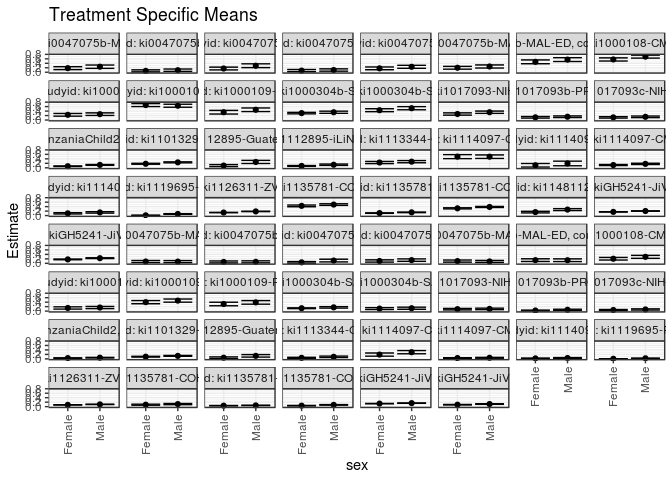

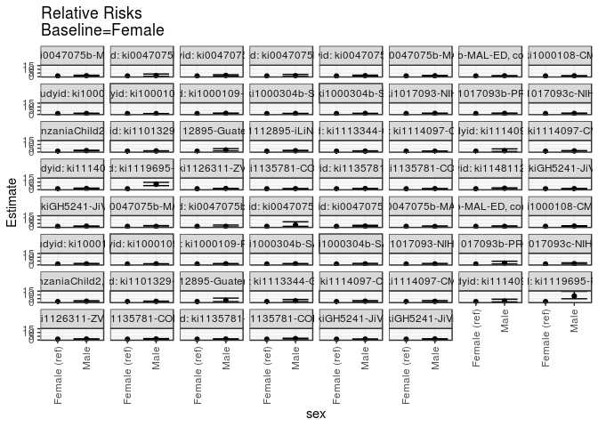

[figure not shown]

[figure not shown]

## Results Table

### Parameter: TSM

| agecat | studyid | country | intervention_level | baseline_level | estimate | ci_lower | ci_upper |
| --- | --- | --- | --- | --- | --- | --- | --- |
| 0-24 months | ki0047075b-MAL-ED | BANGLADESH | Female | NA | 0.1838235 | 0.1186018 | 0.2490452 |
| 0-24 months | ki0047075b-MAL-ED | BANGLADESH | Male | NA | 0.2480620 | 0.1733922 | 0.3227319 |
| 0-24 months | ki0047075b-MAL-ED | BRAZIL | Female | NA | 0.0619469 | 0.0174052 | 0.1064886 |
| 0-24 months | ki0047075b-MAL-ED | BRAZIL | Male | NA | 0.0916667 | 0.0399275 | 0.1434059 |
| 0-24 months | ki0047075b-MAL-ED | INDIA | Female | NA | 0.1666667 | 0.1043636 | 0.2289697 |
| 0-24 months | ki0047075b-MAL-ED | INDIA | Male | NA | 0.2920354 | 0.2080315 | 0.3760393 |
| 0-24 months | ki0047075b-MAL-ED | NEPAL | Female | NA | 0.0727273 | 0.0240965 | 0.1213580 |
| 0-24 months | ki0047075b-MAL-ED | NEPAL | Male | NA | 0.1000000 | 0.0483222 | 0.1516778 |
| 0-24 months | ki0047075b-MAL-ED | PERU | Female | NA | 0.1748252 | 0.1124699 | 0.2371804 |
| 0-24 months | ki0047075b-MAL-ED | PERU | Male | NA | 0.2437500 | 0.1771137 | 0.3103863 |
| 0-24 months | ki0047075b-MAL-ED | SOUTH AFRICA | Female | NA | 0.2012579 | 0.1388381 | 0.2636776 |
| 0-24 months | ki0047075b-MAL-ED | SOUTH AFRICA | Male | NA | 0.2580645 | 0.1890688 | 0.3270602 |
| 0-24 months | ki0047075b-MAL-ED | TANZANIA, UNITED REPUBLIC OF | Female | NA | 0.4661654 | 0.3812227 | 0.5511081 |
| 0-24 months | ki0047075b-MAL-ED | TANZANIA, UNITED REPUBLIC OF | Male | NA | 0.5658915 | 0.4801977 | 0.6515853 |
| 0-24 months | ki1000108-CMC-V-BCS-2002 | INDIA | Female | NA | 0.5721925 | 0.5011848 | 0.6432002 |
| 0-24 months | ki1000108-CMC-V-BCS-2002 | INDIA | Male | NA | 0.6989247 | 0.6329121 | 0.7649374 |
| 0-24 months | ki1000108-IRC | INDIA | Female | NA | 0.2324324 | 0.1714929 | 0.2933720 |
| 0-24 months | ki1000108-IRC | INDIA | Male | NA | 0.2622222 | 0.2046803 | 0.3197642 |
| 0-24 months | ki1000109-EE | PAKISTAN | Female | NA | 0.6702703 | 0.6024374 | 0.7381031 |
| 0-24 months | ki1000109-EE | PAKISTAN | Male | NA | 0.6391753 | 0.5715079 | 0.7068426 |
| 0-24 months | ki1000109-ResPak | PAKISTAN | Female | NA | 0.3484848 | 0.2670523 | 0.4299174 |
| 0-24 months | ki1000109-ResPak | PAKISTAN | Male | NA | 0.4589041 | 0.3779289 | 0.5398794 |
| 0-24 months | ki1000304b-SAS-CompFeed | INDIA | Female | NA | 0.3100000 | 0.2770153 | 0.3429847 |
| 0-24 months | ki1000304b-SAS-CompFeed | INDIA | Male | NA | 0.3481393 | 0.3004483 | 0.3958302 |
| 0-24 months | ki1000304b-SAS-FoodSuppl | INDIA | Female | NA | 0.4394619 | 0.3742422 | 0.5046816 |
| 0-24 months | ki1000304b-SAS-FoodSuppl | INDIA | Male | NA | 0.5282051 | 0.4580549 | 0.5983553 |
| 0-24 months | ki1017093-NIH-Birth | BANGLADESH | Female | NA | 0.2693603 | 0.2188670 | 0.3198536 |
| 0-24 months | ki1017093-NIH-Birth | BANGLADESH | Male | NA | 0.3493976 | 0.2980710 | 0.4007242 |
| 0-24 months | ki1017093b-PROVIDE | BANGLADESH | Female | NA | 0.1204819 | 0.0854412 | 0.1555226 |
| 0-24 months | ki1017093b-PROVIDE | BANGLADESH | Male | NA | 0.1467391 | 0.1105608 | 0.1829175 |

[output cut: 94 more lines]

### Parameter: E(Y)

| agecat | studyid | country | intervention_level | baseline_level | estimate | ci_lower | ci_upper |
| --- | --- | --- | --- | --- | --- | --- | --- |
| 0-24 months | ki0047075b-MAL-ED | BANGLADESH | NA | NA | 0.2150943 | 0.1655300 | 0.2646587 |
| 0-24 months | ki0047075b-MAL-ED | BRAZIL | NA | NA | 0.0772532 | 0.0428971 | 0.1116093 |
| 0-24 months | ki0047075b-MAL-ED | INDIA | NA | NA | 0.2231076 | 0.1714997 | 0.2747154 |
| 0-24 months | ki0047075b-MAL-ED | NEPAL | NA | NA | 0.0875000 | 0.0516764 | 0.1233236 |
| 0-24 months | ki0047075b-MAL-ED | PERU | NA | NA | 0.2112211 | 0.1651858 | 0.2572564 |
| 0-24 months | ki0047075b-MAL-ED | SOUTH AFRICA | NA | NA | 0.2292994 | 0.1827279 | 0.2758709 |
| 0-24 months | ki0047075b-MAL-ED | TANZANIA, UNITED REPUBLIC OF | NA | NA | 0.5152672 | 0.4546361 | 0.5758983 |
| 0-24 months | ki1000108-CMC-V-BCS-2002 | INDIA | NA | NA | 0.6353887 | 0.5864772 | 0.6843003 |
| 0-24 months | ki1000108-IRC | INDIA | NA | NA | 0.2487805 | 0.2068840 | 0.2906770 |
| 0-24 months | ki1000109-EE | PAKISTAN | NA | NA | 0.6543536 | 0.6064106 | 0.7022965 |
| 0-24 months | ki1000109-ResPak | PAKISTAN | NA | NA | 0.4064748 | 0.3486326 | 0.4643170 |
| 0-24 months | ki1000304b-SAS-CompFeed | INDIA | NA | NA | 0.3307241 | 0.3024794 | 0.3589688 |
| 0-24 months | ki1000304b-SAS-FoodSuppl | INDIA | NA | NA | 0.4808612 | 0.4329065 | 0.5288160 |
| 0-24 months | ki1017093-NIH-Birth | BANGLADESH | NA | NA | 0.3116057 | 0.2753823 | 0.3478292 |
| 0-24 months | ki1017093b-PROVIDE | BANGLADESH | NA | NA | 0.1342857 | 0.1090095 | 0.1595619 |
| 0-24 months | ki1017093c-NIH-Crypto | BANGLADESH | NA | NA | 0.1306069 | 0.1066024 | 0.1546113 |
| 0-24 months | ki1066203-TanzaniaChild2 | TANZANIA, UNITED REPUBLIC OF | NA | NA | 0.0997496 | 0.0877482 | 0.1117510 |
| 0-24 months | ki1101329-Keneba | GAMBIA | NA | NA | 0.2123499 | 0.1975010 | 0.2271989 |
| 0-24 months | ki1112895-Guatemala BSC | GUATEMALA | NA | NA | 0.1777778 | 0.1354898 | 0.2200657 |
| 0-24 months | ki1112895-iLiNS-Zinc | BURKINA FASO | NA | NA | 0.1093415 | 0.0900773 | 0.1286057 |
| 0-24 months | ki1113344-GMS-Nepal | NEPAL | NA | NA | 0.2558140 | 0.2209310 | 0.2906969 |
| 0-24 months | ki1114097-CMIN | BANGLADESH | NA | NA | 0.4981949 | 0.4392073 | 0.5571825 |
| 0-24 months | ki1114097-CMIN | BRAZIL | NA | NA | 0.1512605 | 0.0866122 | 0.2159088 |
| 0-24 months | ki1114097-CMIN | GUINEA-BISSAU | NA | NA | 0.1486397 | 0.1306733 | 0.1666060 |
| 0-24 months | ki1114097-CMIN | PERU | NA | NA | 0.1205597 | 0.0996100 | 0.1415095 |
| 0-24 months | ki1119695-PROBIT | BELARUS | NA | NA | 0.0394153 | 0.0310085 | 0.0478221 |
| 0-24 months | ki1126311-ZVITAMBO | ZIMBABWE | NA | NA | 0.1610176 | 0.1549448 | 0.1670903 |
| 0-24 months | ki1135781-COHORTS | GUATEMALA | NA | NA | 0.4641813 | 0.4377440 | 0.4906186 |
| 0-24 months | ki1135781-COHORTS | INDIA | NA | NA | 0.1275448 | 0.1199527 | 0.1351370 |
| 0-24 months | ki1135781-COHORTS | PHILIPPINES | NA | NA | 0.3561151 | 0.3391405 | 0.3730897 |
| 0-24 months | ki1148112-LCNI-5 | MALAWI | NA | NA | 0.2107143 | 0.1831192 | 0.2383093 |
| 0-24 months | kiGH5241-JiVitA-3 | BANGLADESH | NA | NA | 0.1837274 | 0.1781609 | 0.1892940 |
| 0-24 months | kiGH5241-JiVitA-4 | BANGLADESH | NA | NA | 0.2030503 | 0.1912482 | 0.2148525 |
| 0-6 months | ki0047075b-MAL-ED | BANGLADESH | NA | NA | 0.0792453 | 0.0466613 | 0.1118293 |
| 0-6 months | ki0047075b-MAL-ED | BRAZIL | NA | NA | 0.0643777 | 0.0327970 | 0.0959584 |
| 0-6 months | ki0047075b-MAL-ED | INDIA | NA | NA | 0.0796813 | 0.0461133 | 0.1132493 |
| 0-6 months | ki0047075b-MAL-ED | PERU | NA | NA | 0.1254125 | 0.0880603 | 0.1627648 |
| 0-6 months | ki0047075b-MAL-ED | SOUTH AFRICA | NA | NA | 0.0923567 | 0.0602816 | 0.1244318 |
| 0-6 months | ki0047075b-MAL-ED | TANZANIA, UNITED REPUBLIC OF | NA | NA | 0.1412214 | 0.0989722 | 0.1834706 |
| 0-6 months | ki1000108-CMC-V-BCS-2002 | INDIA | NA | NA | 0.2472826 | 0.2031431 | 0.2914222 |
| 0-6 months | ki1000108-IRC | INDIA | NA | NA | 0.1512195 | 0.1164988 | 0.1859402 |
| 0-6 months | ki1000109-EE | PAKISTAN | NA | NA | 0.4353562 | 0.3853744 | 0.4853380 |
| 0-6 months | ki1000109-ResPak | PAKISTAN | NA | NA | 0.3561151 | 0.2997244 | 0.4125058 |
| 0-6 months | ki1000304b-SAS-CompFeed | INDIA | NA | NA | 0.1496732 | 0.1307571 | 0.1685893 |
| 0-6 months | ki1000304b-SAS-FoodSuppl | INDIA | NA | NA | 0.1201923 | 0.0889059 | 0.1514788 |
| 0-6 months | ki1017093-NIH-Birth | BANGLADESH | NA | NA | 0.0937997 | 0.0709973 | 0.1166021 |
| 0-6 months | ki1017093b-PROVIDE | BANGLADESH | NA | NA | 0.0442857 | 0.0290345 | 0.0595370 |
| 0-6 months | ki1017093c-NIH-Crypto | BANGLADESH | NA | NA | 0.0620053 | 0.0448256 | 0.0791849 |
| 0-6 months | ki1066203-TanzaniaChild2 | TANZANIA, UNITED REPUBLIC OF | NA | NA | 0.0438230 | 0.0356249 | 0.0520212 |
| 0-6 months | ki1101329-Keneba | GAMBIA | NA | NA | 0.1164300 | 0.1037657 | 0.1290943 |
| 0-6 months | ki1112895-Guatemala BSC | GUATEMALA | NA | NA | 0.0915254 | 0.0585643 | 0.1244865 |
| 0-6 months | ki1113344-GMS-Nepal | NEPAL | NA | NA | 0.0697674 | 0.0494002 | 0.0901347 |
| 0-6 months | ki1114097-CMIN | BANGLADESH | NA | NA | 0.2527076 | 0.2014394 | 0.3039758 |
| 0-6 months | ki1114097-CMIN | GUINEA-BISSAU | NA | NA | 0.0424870 | 0.0297546 | 0.0552194 |
| 0-6 months | ki1114097-CMIN | PERU | NA | NA | 0.0300429 | 0.0173790 | 0.0427068 |
| 0-6 months | ki1119695-PROBIT | BELARUS | NA | NA | 0.0142071 | 0.0107237 | 0.0176904 |
| 0-6 months | ki1126311-ZVITAMBO | ZIMBABWE | NA | NA | 0.0908832 | 0.0861303 | 0.0956361 |
| 0-6 months | ki1135781-COHORTS | GUATEMALA | NA | NA | 0.1007326 | 0.0828733 | 0.1185919 |
| 0-6 months | ki1135781-COHORTS | INDIA | NA | NA | 0.0491918 | 0.0441876 | 0.0541959 |
| 0-6 months | ki1135781-COHORTS | PHILIPPINES | NA | NA | 0.0624591 | 0.0538810 | 0.0710373 |
| 0-6 months | kiGH5241-JiVitA-3 | BANGLADESH | NA | NA | 0.1466323 | 0.1416239 | 0.1516407 |
| 0-6 months | kiGH5241-JiVitA-4 | BANGLADESH | NA | NA | 0.1013645 | 0.0924445 | 0.1102845 |

### Parameter: RR

| agecat | studyid | country | intervention_level | baseline_level | estimate | ci_lower | ci_upper |
| --- | --- | --- | --- | --- | --- | --- | --- |
| 0-24 months | ki0047075b-MAL-ED | BANGLADESH | Female | Female | 1.0000000 | 1.0000000 | 1.000000 |
| 0-24 months | ki0047075b-MAL-ED | BANGLADESH | Male | Female | 1.3494574 | 0.8473945 | 2.148982 |
| 0-24 months | ki0047075b-MAL-ED | BRAZIL | Female | Female | 1.0000000 | 1.0000000 | 1.000000 |
| 0-24 months | ki0047075b-MAL-ED | BRAZIL | Male | Female | 1.4797619 | 0.5932018 | 3.691316 |
| 0-24 months | ki0047075b-MAL-ED | INDIA | Female | Female | 1.0000000 | 1.0000000 | 1.000000 |
| 0-24 months | ki0047075b-MAL-ED | INDIA | Male | Female | 1.7522124 | 1.0932981 | 2.808244 |
| 0-24 months | ki0047075b-MAL-ED | NEPAL | Female | Female | 1.0000000 | 1.0000000 | 1.000000 |
| 0-24 months | ki0047075b-MAL-ED | NEPAL | Male | Female | 1.3750000 | 0.5905862 | 3.201269 |
| 0-24 months | ki0047075b-MAL-ED | PERU | Female | Female | 1.0000000 | 1.0000000 | 1.000000 |
| 0-24 months | ki0047075b-MAL-ED | PERU | Male | Female | 1.3942500 | 0.8895555 | 2.185286 |
| 0-24 months | ki0047075b-MAL-ED | SOUTH AFRICA | Female | Female | 1.0000000 | 1.0000000 | 1.000000 |
| 0-24 months | ki0047075b-MAL-ED | SOUTH AFRICA | Male | Female | 1.2822581 | 0.8514151 | 1.931121 |
| 0-24 months | ki0047075b-MAL-ED | TANZANIA, UNITED REPUBLIC OF | Female | Female | 1.0000000 | 1.0000000 | 1.000000 |
| 0-24 months | ki0047075b-MAL-ED | TANZANIA, UNITED REPUBLIC OF | Male | Female | 1.2139285 | 0.9578495 | 1.538469 |
| 0-24 months | ki1000108-CMC-V-BCS-2002 | INDIA | Female | Female | 1.0000000 | 1.0000000 | 1.000000 |
| 0-24 months | ki1000108-CMC-V-BCS-2002 | INDIA | Male | Female | 1.2214853 | 1.0451039 | 1.427634 |
| 0-24 months | ki1000108-IRC | INDIA | Female | Female | 1.0000000 | 1.0000000 | 1.000000 |
| 0-24 months | ki1000108-IRC | INDIA | Male | Female | 1.1281654 | 0.8014734 | 1.588022 |
| 0-24 months | ki1000109-EE | PAKISTAN | Female | Female | 1.0000000 | 1.0000000 | 1.000000 |
| 0-24 months | ki1000109-EE | PAKISTAN | Male | Female | 0.9536082 | 0.8236915 | 1.104016 |
| 0-24 months | ki1000109-ResPak | PAKISTAN | Female | Female | 1.0000000 | 1.0000000 | 1.000000 |
| 0-24 months | ki1000109-ResPak | PAKISTAN | Male | Female | 1.3168553 | 0.9825855 | 1.764842 |
| 0-24 months | ki1000304b-SAS-CompFeed | INDIA | Female | Female | 1.0000000 | 1.0000000 | 1.000000 |
| 0-24 months | ki1000304b-SAS-CompFeed | INDIA | Male | Female | 1.1230299 | 0.9326578 | 1.352260 |
| 0-24 months | ki1000304b-SAS-FoodSuppl | INDIA | Female | Female | 1.0000000 | 1.0000000 | 1.000000 |
| 0-24 months | ki1000304b-SAS-FoodSuppl | INDIA | Male | Female | 1.2019362 | 0.9848930 | 1.466810 |
| 0-24 months | ki1017093-NIH-Birth | BANGLADESH | Female | Female | 1.0000000 | 1.0000000 | 1.000000 |
| 0-24 months | ki1017093-NIH-Birth | BANGLADESH | Male | Female | 1.2971386 | 1.0222458 | 1.645953 |
| 0-24 months | ki1017093b-PROVIDE | BANGLADESH | Female | Female | 1.0000000 | 1.0000000 | 1.000000 |
| 0-24 months | ki1017093b-PROVIDE | BANGLADESH | Male | Female | 1.2179348 | 0.8318349 | 1.783245 |

[output cut: 94 more lines]

### Parameter: PAR

| agecat | studyid | country | intervention_level | baseline_level | estimate | ci_lower | ci_upper |
| --- | --- | --- | --- | --- | --- | --- | --- |
| 0-24 months | ki0047075b-MAL-ED | BANGLADESH | Female | NA | 0.0312708 | -0.0171467 | 0.0796883 |
| 0-24 months | ki0047075b-MAL-ED | BRAZIL | Female | NA | 0.0153063 | -0.0199065 | 0.0505192 |
| 0-24 months | ki0047075b-MAL-ED | INDIA | Female | NA | 0.0564409 | 0.0087256 | 0.1041562 |
| 0-24 months | ki0047075b-MAL-ED | NEPAL | Female | NA | 0.0147727 | -0.0237034 | 0.0532488 |
| 0-24 months | ki0047075b-MAL-ED | PERU | Female | NA | 0.0363959 | -0.0119507 | 0.0847426 |
| 0-24 months | ki0047075b-MAL-ED | SOUTH AFRICA | Female | NA | 0.0280415 | -0.0179940 | 0.0740770 |
| 0-24 months | ki0047075b-MAL-ED | TANZANIA, UNITED REPUBLIC OF | Female | NA | 0.0491018 | -0.0106140 | 0.1088175 |
| 0-24 months | ki1000108-CMC-V-BCS-2002 | INDIA | Female | NA | 0.0631962 | 0.0144231 | 0.1119694 |
| 0-24 months | ki1000108-IRC | INDIA | Female | NA | 0.0163481 | -0.0296696 | 0.0623657 |
| 0-24 months | ki1000109-EE | PAKISTAN | Female | NA | -0.0159167 | -0.0649859 | 0.0331525 |
| 0-24 months | ki1000109-ResPak | PAKISTAN | Female | NA | 0.0579900 | -0.0026703 | 0.1186502 |
| 0-24 months | ki1000304b-SAS-CompFeed | INDIA | Female | NA | 0.0207241 | -0.0136409 | 0.0550890 |
| 0-24 months | ki1000304b-SAS-FoodSuppl | INDIA | Female | NA | 0.0413994 | -0.0034864 | 0.0862851 |
| 0-24 months | ki1017093-NIH-Birth | BANGLADESH | Female | NA | 0.0422455 | 0.0041140 | 0.0803769 |
| 0-24 months | ki1017093b-PROVIDE | BANGLADESH | Female | NA | 0.0138038 | -0.0126921 | 0.0402997 |
| 0-24 months | ki1017093c-NIH-Crypto | BANGLADESH | Female | NA | 0.0124966 | -0.0113919 | 0.0363852 |
| 0-24 months | ki1066203-TanzaniaChild2 | TANZANIA, UNITED REPUBLIC OF | Female | NA | 0.0296482 | 0.0175442 | 0.0417522 |
| 0-24 months | ki1101329-Keneba | GAMBIA | Female | NA | 0.0332454 | 0.0179352 | 0.0485557 |
| 0-24 months | ki1112895-Guatemala BSC | GUATEMALA | Female | NA | 0.0790123 | 0.0374459 | 0.1205788 |
| 0-24 months | ki1112895-iLiNS-Zinc | BURKINA FASO | Female | NA | 0.0262646 | 0.0098180 | 0.0427111 |
| 0-24 months | ki1113344-GMS-Nepal | NEPAL | Female | NA | 0.0197028 | -0.0166413 | 0.0560470 |
| 0-24 months | ki1114097-CMIN | BANGLADESH | Female | NA | -0.0018051 | -0.0692766 | 0.0656665 |
| 0-24 months | ki1114097-CMIN | BRAZIL | Female | NA | 0.0383573 | -0.0242243 | 0.1009389 |
| 0-24 months | ki1114097-CMIN | GUINEA-BISSAU | Female | NA | 0.0259484 | 0.0080730 | 0.0438238 |
| 0-24 months | ki1114097-CMIN | PERU | Female | NA | 0.0214606 | -0.0002883 | 0.0432096 |
| 0-24 months | ki1119695-PROBIT | BELARUS | Female | NA | 0.0294645 | 0.0236565 | 0.0352725 |
| 0-24 months | ki1126311-ZVITAMBO | ZIMBABWE | Female | NA | 0.0258112 | 0.0195847 | 0.0320377 |
| 0-24 months | ki1135781-COHORTS | GUATEMALA | Female | NA | 0.0309515 | 0.0029400 | 0.0589630 |
| 0-24 months | ki1135781-COHORTS | INDIA | Female | NA | 0.0175279 | 0.0096507 | 0.0254052 |
| 0-24 months | ki1135781-COHORTS | PHILIPPINES | Female | NA | 0.0325243 | 0.0145422 | 0.0505064 |
| 0-24 months | ki1148112-LCNI-5 | MALAWI | Female | NA | 0.0563200 | 0.0287764 | 0.0838635 |
| 0-24 months | kiGH5241-JiVitA-3 | BANGLADESH | Female | NA | 0.0197011 | 0.0149069 | 0.0244953 |
| 0-24 months | kiGH5241-JiVitA-4 | BANGLADESH | Female | NA | 0.0272060 | 0.0154035 | 0.0390085 |
| 0-6 months | ki0047075b-MAL-ED | BANGLADESH | Female | NA | -0.0016371 | -0.0333552 | 0.0300811 |
| 0-6 months | ki0047075b-MAL-ED | BRAZIL | Female | NA | 0.0024308 | -0.0300799 | 0.0349415 |
| 0-6 months | ki0047075b-MAL-ED | INDIA | Female | NA | 0.0362030 | 0.0044061 | 0.0679999 |
| 0-6 months | ki0047075b-MAL-ED | PERU | Female | NA | 0.0205174 | -0.0186893 | 0.0597242 |
| 0-6 months | ki0047075b-MAL-ED | SOUTH AFRICA | Female | NA | -0.0082722 | -0.0399087 | 0.0233642 |
| 0-6 months | ki0047075b-MAL-ED | TANZANIA, UNITED REPUBLIC OF | Female | NA | -0.0016358 | -0.0432386 | 0.0399670 |
| 0-6 months | ki1000108-CMC-V-BCS-2002 | INDIA | Female | NA | 0.0418772 | -0.0020526 | 0.0858070 |
| 0-6 months | ki1000108-IRC | INDIA | Female | NA | 0.0106790 | -0.0274107 | 0.0487686 |
| 0-6 months | ki1000109-EE | PAKISTAN | Female | NA | 0.0353562 | -0.0157988 | 0.0865112 |
| 0-6 months | ki1000109-ResPak | PAKISTAN | Female | NA | 0.0379333 | -0.0212191 | 0.0970857 |
| 0-6 months | ki1000304b-SAS-CompFeed | INDIA | Female | NA | 0.0211018 | -0.0004627 | 0.0426662 |
| 0-6 months | ki1000304b-SAS-FoodSuppl | INDIA | Female | NA | 0.0075797 | -0.0217831 | 0.0369425 |
| 0-6 months | ki1017093-NIH-Birth | BANGLADESH | Female | NA | 0.0062576 | -0.0177743 | 0.0302895 |
| 0-6 months | ki1017093b-PROVIDE | BANGLADESH | Female | NA | 0.0171773 | 0.0014192 | 0.0329354 |
| 0-6 months | ki1017093c-NIH-Crypto | BANGLADESH | Female | NA | 0.0121365 | -0.0049695 | 0.0292425 |
| 0-6 months | ki1066203-TanzaniaChild2 | TANZANIA, UNITED REPUBLIC OF | Female | NA | 0.0091947 | 0.0009195 | 0.0174698 |
| 0-6 months | ki1101329-Keneba | GAMBIA | Female | NA | 0.0185397 | 0.0054469 | 0.0316325 |
| 0-6 months | ki1112895-Guatemala BSC | GUATEMALA | Female | NA | 0.0395774 | 0.0074509 | 0.0717039 |
| 0-6 months | ki1113344-GMS-Nepal | NEPAL | Female | NA | 0.0246286 | 0.0036596 | 0.0455975 |
| 0-6 months | ki1114097-CMIN | BANGLADESH | Female | NA | 0.0610409 | 0.0036536 | 0.1184283 |
| 0-6 months | ki1114097-CMIN | GUINEA-BISSAU | Female | NA | 0.0065462 | -0.0064021 | 0.0194946 |
| 0-6 months | ki1114097-CMIN | PERU | Female | NA | 0.0085045 | -0.0048320 | 0.0218409 |
| 0-6 months | ki1119695-PROBIT | BELARUS | Female | NA | 0.0111182 | 0.0084219 | 0.0138144 |
| 0-6 months | ki1126311-ZVITAMBO | ZIMBABWE | Female | NA | 0.0113461 | 0.0064722 | 0.0162199 |
| 0-6 months | ki1135781-COHORTS | GUATEMALA | Female | NA | 0.0143602 | -0.0042306 | 0.0329511 |
| 0-6 months | ki1135781-COHORTS | INDIA | Female | NA | 0.0058009 | 0.0006608 | 0.0109411 |
| 0-6 months | ki1135781-COHORTS | PHILIPPINES | Female | NA | 0.0186178 | 0.0096551 | 0.0275805 |
| 0-6 months | kiGH5241-JiVitA-3 | BANGLADESH | Female | NA | 0.0104592 | 0.0060010 | 0.0149174 |
| 0-6 months | kiGH5241-JiVitA-4 | BANGLADESH | Female | NA | 0.0142565 | 0.0050926 | 0.0234205 |

### Parameter: PAF

| agecat | studyid | country | intervention_level | baseline_level | estimate | ci_lower | ci_upper |
| --- | --- | --- | --- | --- | --- | --- | --- |
| 0-24 months | ki0047075b-MAL-ED | BANGLADESH | Female | NA | 0.1453818 | -0.1104170 | 0.3422541 |
| 0-24 months | ki0047075b-MAL-ED | BRAZIL | Female | NA | 0.1981318 | -0.4026375 | 0.5415832 |
| 0-24 months | ki0047075b-MAL-ED | INDIA | Female | NA | 0.2529762 | 0.0114853 | 0.4354716 |
| 0-24 months | ki0047075b-MAL-ED | NEPAL | Female | NA | 0.1688312 | -0.4029836 | 0.5075911 |
| 0-24 months | ki0047075b-MAL-ED | PERU | Female | NA | 0.1723121 | -0.0890912 | 0.3709734 |
| 0-24 months | ki0047075b-MAL-ED | SOUTH AFRICA | Female | NA | 0.1222921 | -0.1023672 | 0.3011665 |
| 0-24 months | ki0047075b-MAL-ED | TANZANIA, UNITED REPUBLIC OF | Female | NA | 0.0952938 | -0.0289176 | 0.2045103 |
| 0-24 months | ki1000108-CMC-V-BCS-2002 | INDIA | Female | NA | 0.0994607 | 0.0184481 | 0.1737870 |
| 0-24 months | ki1000108-IRC | INDIA | Female | NA | 0.0657128 | -0.1386877 | 0.2334223 |
| 0-24 months | ki1000109-EE | PAKISTAN | Female | NA | -0.0243243 | -0.1021919 | 0.0480420 |
| 0-24 months | ki1000109-ResPak | PAKISTAN | Female | NA | 0.1426656 | -0.0206317 | 0.2798360 |
| 0-24 months | ki1000304b-SAS-CompFeed | INDIA | Female | NA | 0.0626627 | -0.0446081 | 0.1589179 |
| 0-24 months | ki1000304b-SAS-FoodSuppl | INDIA | Female | NA | 0.0860942 | -0.0124865 | 0.1750765 |
| 0-24 months | ki1017093-NIH-Birth | BANGLADESH | Female | NA | 0.1355734 | 0.0043719 | 0.2494855 |
| 0-24 months | ki1017093b-PROVIDE | BANGLADESH | Female | NA | 0.1027942 | -0.1170392 | 0.2793643 |
| 0-24 months | ki1017093c-NIH-Crypto | BANGLADESH | Female | NA | 0.0956812 | -0.1062779 | 0.2607712 |
| 0-24 months | ki1066203-TanzaniaChild2 | TANZANIA, UNITED REPUBLIC OF | Female | NA | 0.2972266 | 0.1701477 | 0.4048454 |
| 0-24 months | ki1101329-Keneba | GAMBIA | Female | NA | 0.1565597 | 0.0817841 | 0.2252459 |
| 0-24 months | ki1112895-Guatemala BSC | GUATEMALA | Female | NA | 0.4444444 | 0.1820801 | 0.6226501 |
| 0-24 months | ki1112895-iLiNS-Zinc | BURKINA FASO | Female | NA | 0.2402069 | 0.0861335 | 0.3683042 |
| 0-24 months | ki1113344-GMS-Nepal | NEPAL | Female | NA | 0.0770202 | -0.0764047 | 0.2085768 |
| 0-24 months | ki1114097-CMIN | BANGLADESH | Female | NA | -0.0036232 | -0.1486190 | 0.1230691 |
| 0-24 months | ki1114097-CMIN | BRAZIL | Female | NA | 0.2535842 | -0.2810532 | 0.5650949 |
| 0-24 months | ki1114097-CMIN | GUINEA-BISSAU | Female | NA | 0.1745724 | 0.0466421 | 0.2853359 |
| 0-24 months | ki1114097-CMIN | PERU | Female | NA | 0.1780084 | -0.0211489 | 0.3383235 |
| 0-24 months | ki1119695-PROBIT | BELARUS | Female | NA | 0.7475391 | 0.6705580 | 0.8065319 |
| 0-24 months | ki1126311-ZVITAMBO | ZIMBABWE | Female | NA | 0.1603007 | 0.1210634 | 0.1977864 |
| 0-24 months | ki1135781-COHORTS | GUATEMALA | Female | NA | 0.0666797 | 0.0042614 | 0.1251853 |
| 0-24 months | ki1135781-COHORTS | INDIA | Female | NA | 0.1374258 | 0.0738370 | 0.1966486 |
| 0-24 months | ki1135781-COHORTS | PHILIPPINES | Female | NA | 0.0913308 | 0.0394053 | 0.1404495 |
| 0-24 months | ki1148112-LCNI-5 | MALAWI | Female | NA | 0.2672813 | 0.1276227 | 0.3845820 |
| 0-24 months | kiGH5241-JiVitA-3 | BANGLADESH | Female | NA | 0.1072301 | 0.0808995 | 0.1328065 |
| 0-24 months | kiGH5241-JiVitA-4 | BANGLADESH | Female | NA | 0.1339865 | 0.0739985 | 0.1900883 |
| 0-6 months | ki0047075b-MAL-ED | BANGLADESH | Female | NA | -0.0206583 | -0.5106301 | 0.3103915 |
| 0-6 months | ki0047075b-MAL-ED | BRAZIL | Female | NA | 0.0377581 | -0.6258323 | 0.4305013 |
| 0-6 months | ki0047075b-MAL-ED | INDIA | Female | NA | 0.4543478 | -0.0459568 | 0.7153455 |
| 0-6 months | ki0047075b-MAL-ED | PERU | Female | NA | 0.1635996 | -0.2112544 | 0.4224453 |
| 0-6 months | ki0047075b-MAL-ED | SOUTH AFRICA | Female | NA | -0.0895684 | -0.4905703 | 0.2035536 |
| 0-6 months | ki0047075b-MAL-ED | TANZANIA, UNITED REPUBLIC OF | Female | NA | -0.0115830 | -0.3535390 | 0.2439818 |
| 0-6 months | ki1000108-CMC-V-BCS-2002 | INDIA | Female | NA | 0.1693496 | -0.0272770 | 0.3283407 |
| 0-6 months | ki1000108-IRC | INDIA | Female | NA | 0.0706190 | -0.2182434 | 0.2909881 |
| 0-6 months | ki1000109-EE | PAKISTAN | Female | NA | 0.0812121 | -0.0443088 | 0.1916460 |
| 0-6 months | ki1000109-ResPak | PAKISTAN | Female | NA | 0.1065197 | -0.0760159 | 0.2580900 |
| 0-6 months | ki1000304b-SAS-CompFeed | INDIA | Female | NA | 0.1409857 | -0.0038641 | 0.2649347 |
| 0-6 months | ki1000304b-SAS-FoodSuppl | INDIA | Female | NA | 0.0630631 | -0.2155102 | 0.2777923 |
| 0-6 months | ki1017093-NIH-Birth | BANGLADESH | Female | NA | 0.0667123 | -0.2275646 | 0.2904439 |
| 0-6 months | ki1017093b-PROVIDE | BANGLADESH | Female | NA | 0.3878741 | -0.0517628 | 0.6437427 |
| 0-6 months | ki1017093c-NIH-Crypto | BANGLADESH | Female | NA | 0.1957335 | -0.1266196 | 0.4258536 |
| 0-6 months | ki1066203-TanzaniaChild2 | TANZANIA, UNITED REPUBLIC OF | Female | NA | 0.2098134 | 0.0013534 | 0.3747589 |
| 0-6 months | ki1101329-Keneba | GAMBIA | Female | NA | 0.1592349 | 0.0401075 | 0.2635780 |
| 0-6 months | ki1112895-Guatemala BSC | GUATEMALA | Female | NA | 0.4324194 | 0.0044090 | 0.6764257 |
| 0-6 months | ki1113344-GMS-Nepal | NEPAL | Female | NA | 0.3530092 | -0.0037780 | 0.5829785 |
| 0-6 months | ki1114097-CMIN | BANGLADESH | Female | NA | 0.2415476 | -0.0197142 | 0.4358713 |
| 0-6 months | ki1114097-CMIN | GUINEA-BISSAU | Female | NA | 0.1540762 | -0.2081598 | 0.4077049 |
| 0-6 months | ki1114097-CMIN | PERU | Female | NA | 0.2830769 | -0.3029722 | 0.6055337 |
| 0-6 months | ki1119695-PROBIT | BELARUS | Female | NA | 0.7825807 | 0.6442434 | 0.8671250 |
| 0-6 months | ki1126311-ZVITAMBO | ZIMBABWE | Female | NA | 0.1248424 | 0.0698873 | 0.1765505 |
| 0-6 months | ki1135781-COHORTS | GUATEMALA | Female | NA | 0.1425580 | -0.0616268 | 0.3074716 |
| 0-6 months | ki1135781-COHORTS | INDIA | Female | NA | 0.1179251 | 0.0076991 | 0.2159071 |
| 0-6 months | ki1135781-COHORTS | PHILIPPINES | Female | NA | 0.2980795 | 0.1454556 | 0.4234444 |
| 0-6 months | kiGH5241-JiVitA-3 | BANGLADESH | Female | NA | 0.0713297 | 0.0405444 | 0.1011272 |
| 0-6 months | kiGH5241-JiVitA-4 | BANGLADESH | Female | NA | 0.1406459 | 0.0463771 | 0.2255960 |